# Winning Hearts and Minds or Stoking Resentment? Exploring the Effects of Chinese Foreign Aid on Africans’ Perceptions of China

2018 NCCU Institute for International Relations Conference

Evan Jones University of Maryland

03 December, 2018

## Geopolitics of China’s Foreign Aid

- Between 2000-12, Africa received 52 billion (2014 USD deflated) in aid (Bluhm et al. 2018)
- 2017 US National Security White Paper: Economically counter “China’s often extractive economic footprint on the continent [Africa]”
- 2018 Forum on China-Africa Cooperation: Xi Jinping pledges another $60 billion in aid to African countries
- 2018 US BUILD Act: doubles Overseas Private Investment Corporation budget and legalizes equity stakes

## Is Aid All Geopolitics?

Aid as an instrument of geopolitics (Morgenthau 1962; Alesina and Dollar 2000; Dreher and Fuchs 2015)

But it has important soft power implications

Tangible impacts of Chinese Aid:

## Research Questions

1. What is the effect of foreign aid on individuals’ attitudes toward donor countries, in particular China?
2. More generally, does aid and investment win hearts and minds or stoke resentments?
3. What are the mechanisms through which aid influences individual’s opinions?
4. Do ODA-like and OOF aid have differential effects?

## Theory

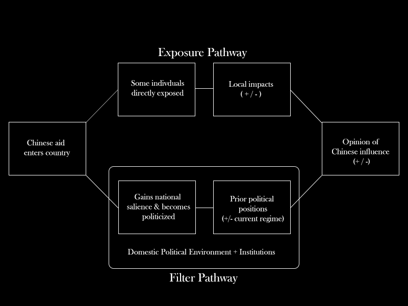

## Data

**DV** “Now let’s talk about the role that China plays in our country. In general, do you think that China’s economic and political influence on [ENTER COUNTRY] is mostly positive, or mostly negative, or haven’t you heard enough to say”? (Q81b)

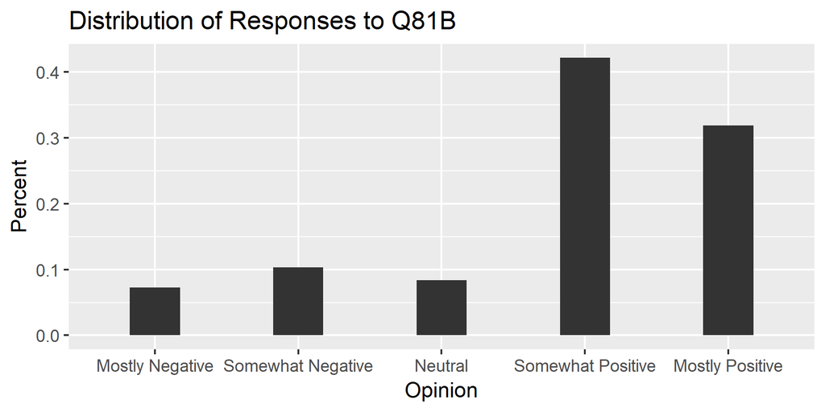

- Use Geocoded Afrobarometer Round 6 Survey (BenYishay et al. 2017)

## Data

**IV** Pair 37,896 respondents to projects within 25 km bandwidth  
Receive one of three treatments: ODA, OOF, Vague

- AidData’s Geocoded Global Chinese Official Finance v1.1.1 (Bluhm et al. 2018)

## Geographic Distribution of Chinese Aid and Investment

[interactive chart not shown]

Diameter denotes relative monetary values

## Controls and Weighting Technique

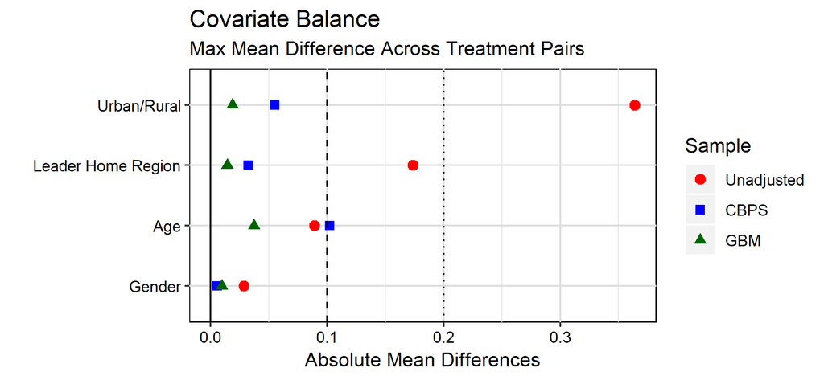

Probability of receiving different treatment types *not* random Reweight data set to induce balance on control variables Chosen method: Gradient Boosting (GBM) estimated propensity score

## Comparing Weighting Techniques

GBM vs Logit: Bias-Variance Trade-off

|  | Logit Est. | Logit SE | GBM Est. | GBM SE |
| --- | --- | --- | --- | --- |
| ODA | 0.0310 | 2.6056 | 0.0284 | 0.0134 |
| OOF | -0.3606 | 2.6083 | -0.3143 | 0.0136 |
| Vague | -0.0967 | 2.5773 | -0.0921 | 0.0133 |
| urbrur | 0.1748 | 1.8480 | 0.1500 | 0.0096 |
| age | -0.0016 | 0.0693 | -0.0007 | 0.0004 |
| female | -0.0262 | 1.8362 | -0.0340 | 0.0096 |
| home_region | 0.3986 | 2.4150 | 0.4314 | 0.0126 |

## Results

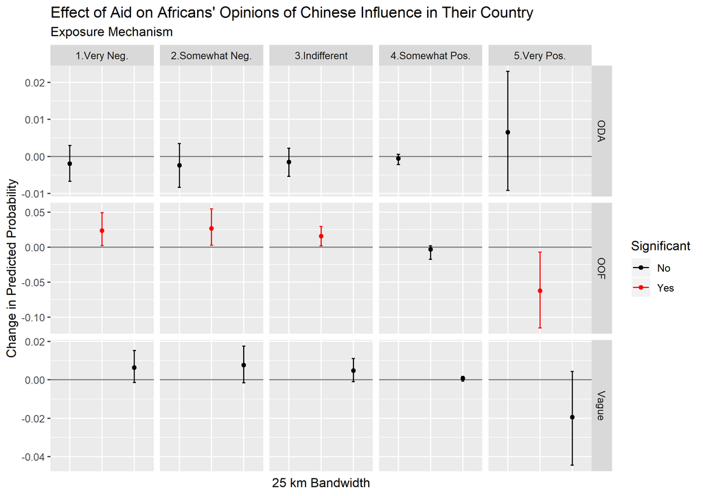

## Conclusions and Moving Forward

- Only OOF matters; stokes negative resentments of China
- ODA does not generate goodwill, even among beneficiaries

Exposure Mechanism:

- strategy to account for aid project heterogeneity?
- bipartite network model weighted by distance to project?

Filter Mechanism:

- need way to directly measure changes in domestic debates
- identify if debates divided by political cleavages

## Bibliography

1. Alesina, Alberto and David Dollar. 2000. “Who Gives Foreign Aid to Whom and Why?” *Journal of Economic Growth* 5(1): 33-63.

2. BenYishay, Ariel, Bradley Parks, Daniel Runfola, and Rachel Trichler. 2016. “Forest Cover Impacts of Chinese Development Projects in Ecologically Sensitive Areas.” AidData Working Paper #32. Williamsburg, VA: AidData. Accessed at http://aiddata.org/working-papers.

3. BenYishay, Ariel, Rotberg, R. Wells, J., Lv Z., Goodman, S., Kovacevic, L., Runfola, D. 2017. “Geocoding Afrobarometer Rounds 1-6: Methodology & Data Quality. AidData: Available online at http://geo.aiddata.org.

4. Bluhm, Richard, Axel Dreher, Andreas Fuchs, Bradley Parks, Austin Strange, and Michael Tierney. 2018. “Connective Financing: Chinese Infrastructure Projects and the Diffusion of Economic Activity in Developing Countries.” AidData Working Paper #64. Williamsburg, VA: AidData. Accessed at https://www.aiddata.org/publications/connective-finance-chinese-infrastructure-projects.

5. Dreher, Axel and Andreas Fuchs. 2015. “Rogue Aid? An Empirical Analysis of China’s Aid Allocation.” *Canadian Journal of Economics* 48: 988-1023.

6. Dreher, Axel, Andreas Fuchs, Bradley Parks, Austin M. Strange, and Michael J. Tierney. 2017. “Aid, China, and Growth: Evidence from a New Global Development Finance Dataset.” AidData Working Paper #46. Williamsburg, VA: AidData. Accessed at http://aiddata.org/working-papers.

7. Isaksson, Ann Sofie, and Andreas Kotsadam. 2018. “Chinese Aid and Local Corruption.” *Journal of Public Economics* 159: 146-159.

Morgenthau, Hans. 1962. “A Political Theory of Foreign Aid.” *American Political Science Review* 56(2): 301-9.